# Harvest

Matt

21 7 2020

Often conservation bodies are concerned with regulating legal harvest on species. The newly developed “Harvest” package helps conservation managers to make decisions.

```r
# You might need to install the devtools package
#install.packages("devtools") # delete the "#" at the start of the line to run this code
library("devtools")
#install_github("NathanWhitmore/harvest", build_vignettes = TRUE) # we are installing a newly developed package so here we use a command "install_github" which allows us to install the development version of the package (be aware that the package may be unstable when installed from github and you may have to update it quite often)
library(harvest)
#vignette("harvest") # This is the help file is you want to look at it delete the first "# "
```

Lets add some vital rates for our population. Here we are using some made-up vital rates. Let us imagine of our species is the “Sarmaree”.

```r
lambda_PM(
  a = 2,        # age of first reproduction
  b = 3.25,     # number of offspring per female
  w = 4,        # max age of reproduction
  la = 0.15,    # survival rate to adult (not annual)
  p = 0.7       # annual survival rate as adult
)
```

```
## $`Lambda:`
## [1] 1.024013
```

This function determines the average lamda value (the finite growth rate). We can also change this to staged model where we look at the stages of the population and develop a transition matrix (which George will tell you about this week)

```r
lambda_matrix(
  r.stage = 2 ,    # stage of first reproduction
  b = 3.25,  # number of female offspring per female
  stages = 4, # number of stages
  S = c(0.7,rep(0.7,3)),  # survival rate vector
  terminal =FALSE # Does the last stage have to die or can they survive longer?
)
```

```
## $`Transition matrix`
##           [,1]  [,2]  [,3]  [,4]
## Fecundity  0.0 2.275 2.275 2.275
## Survival   0.7 0.000 0.000 0.000
## Survival   0.0 0.700 0.000 0.000
## Survival   0.0 0.000 0.700 0.700
##
## $`Lambda:`
## [1] 1.65958
```

This creates the Transition matrix.

From this we can look at which part of the matrix has more of an effect on the finite rate of growth.

```r
elasticity(pop.matrix)
```

```
##                [,1]      [,2]       [,3]       [,4]
## Fecundity 0.0000000 0.2118372 0.08935153 0.06518067
## Survival  0.3663694 0.0000000 0.00000000 0.00000000
## Survival  0.0000000 0.1545322 0.00000000 0.00000000
## Survival  0.0000000 0.0000000 0.06518067 0.04754837
```

First stage survival is the most critical to the estimate of growth rate. We could focus data collection on this vital rate and design studies to look at this in juvenile Sarmaree.

How tolerance is the Sarmaree to harvest? We can use the harvest_tolerance function to explore this.

```r
harvest_tolerance(seed = 0,
  name = "Sarmaree",
  site = "Popa Mountain National Park ",
  iterations = 100000,
  area = 21,
  units ="ha",
  threshold = 0,
  growth = rnorm(100000, mean=1.65, sd =0.3),#lamda
  density = runif(100000, min=3, max=15),# density
  biomass = rnorm(100000, mean=30, sd =15),
  offtake = rnorm(100000, mean=520, sd =60) # 10kg per week
)
```

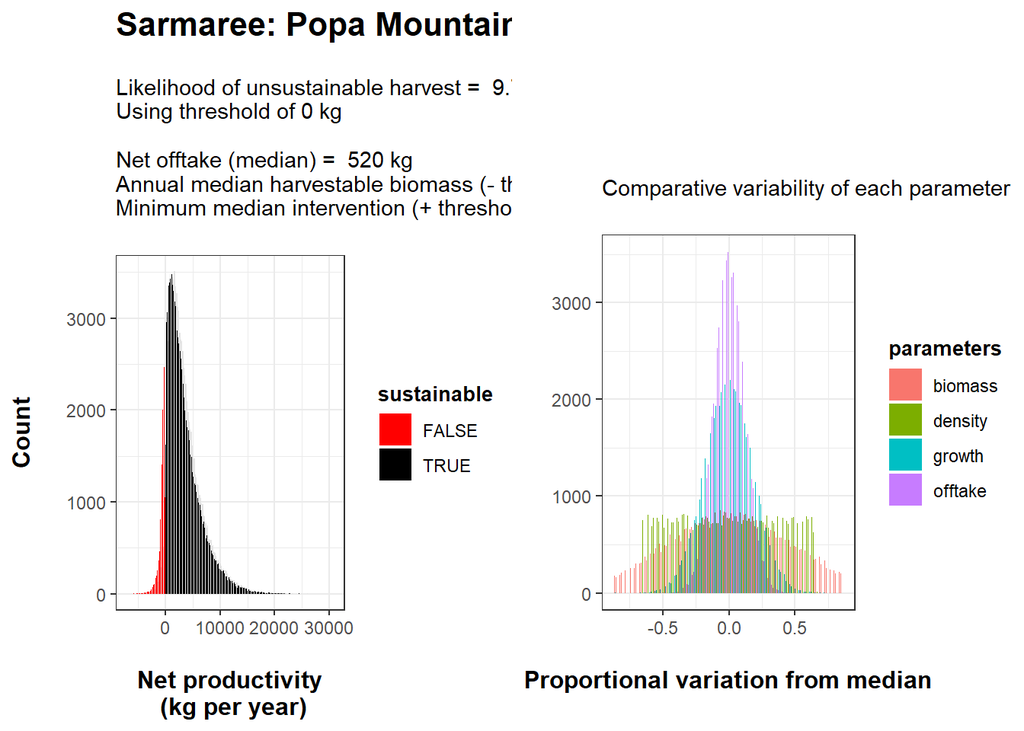

These plots show the probability if unsustainable harvest. In grey is the non-harvest scenario. The net productivity (after the harvest) is shown in red and black. Red indicates unsustainable harvest. The other plot shows the distribution of the parameters.

## Your task

Find vital rates for a real species and then show how different harvest levels could influence the probability of unsustainable harvest. Use code blocks and text (i.e. use a RMarkdown file - .rmd) to write a report about the species and show the effect of harvest. Explain what the most important variables are for determining sustainable harvest. What would happen if we increase/decrease annual survival and fecundancy through conservation measures?

Write at least 500 words.